# scale_x_continuous/scale_y_continuous

# 準備

```r
#ライブラリの読み込み．なければインストールする．
if(!require(ggplot2)){
  install.packages("ggplot2")
  library(ggplot2)
}
```

ここでは軸目盛りを操作するための scale_x_continuous / scale_y_continuous の使い方を説明します．

まず，具体例として2次関数
$$y = x^2$$
のグラフを描きます．

```r
# -100から100まで連続値を作成する
x <- seq(-100,100,1)
y <- x^2
# データフレームを作る
d<-data.frame(x,y)
# データの先頭を表示する
head(d)
```

```
##      x     y
## 1 -100 10000
## 2  -99  9801
## 3  -98  9604
## 4  -97  9409
## 5  -96  9216
## 6  -95  9025
```

```r
# データの末尾を表示する
tail(d)
```

```
##       x     y
## 196  95  9025
## 197  96  9216
## 198  97  9409
## 199  98  9604
## 200  99  9801
## 201 100 10000
```

```r
g<-ggplot(d,aes(x=x,y=y))+geom_line()
g
```

[output not shown]

こういった場合 scale_x_continuous / scale_y_continuous を使うと軸目盛りや軸ラベルをカスタマイズすることができます．

# scale_x_continuous

まず，X軸を scale_x_continuous を使って操作します．

まず，X軸の目盛りを10刻みにします．

```r
#10刻みで連続値を作成する
seq(-100,100,10)
```

```
##  [1] -100  -90  -80  -70  -60  -50  -40  -30  -20  -10    0   10   20   30
## [15]   40   50   60   70   80   90  100
```

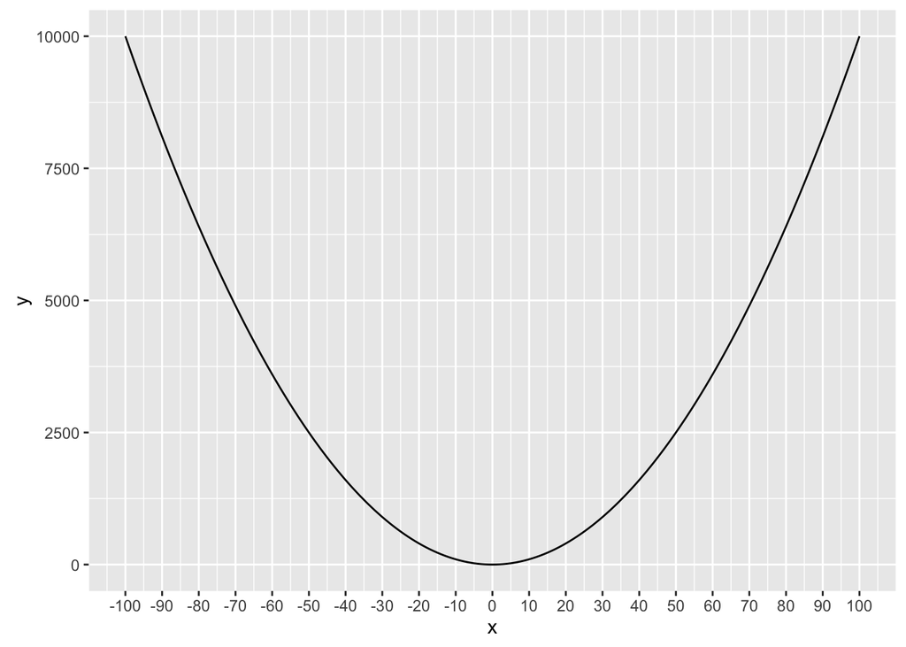

```r
g + scale_x_continuous(breaks=seq(-100,100,10),labels=seq(-100,100,10))
```

breaks と labels の値が同じ場合は labels は省略できます．

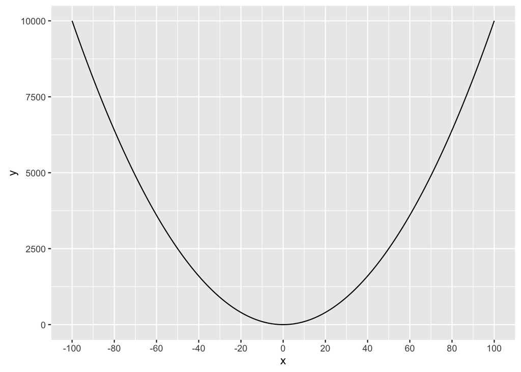

```r
# 20刻みにする
g + scale_x_continuous(breaks=seq(-100,100,20))
```

軸目盛りのラベルを変更したい場合は labels に値を設定します．

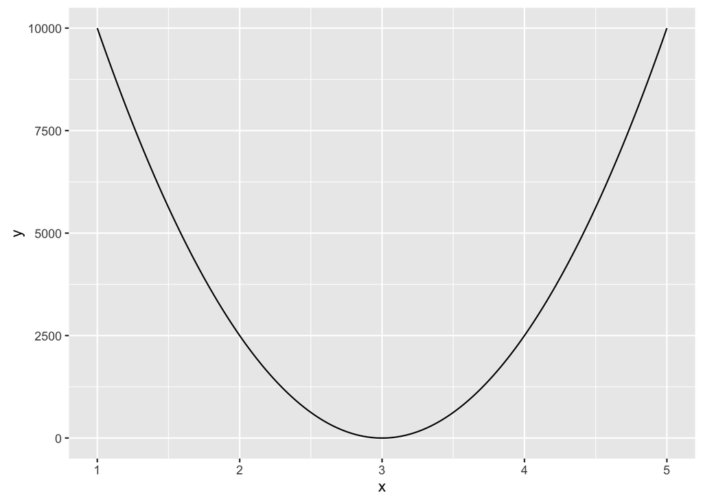

```r
# 50刻みにする,X軸ラベルは1から5とする
g + scale_x_continuous(breaks=seq(-100,100,50),labels=seq(1,5))
```

軸ラベルは数値でなくても構いません．

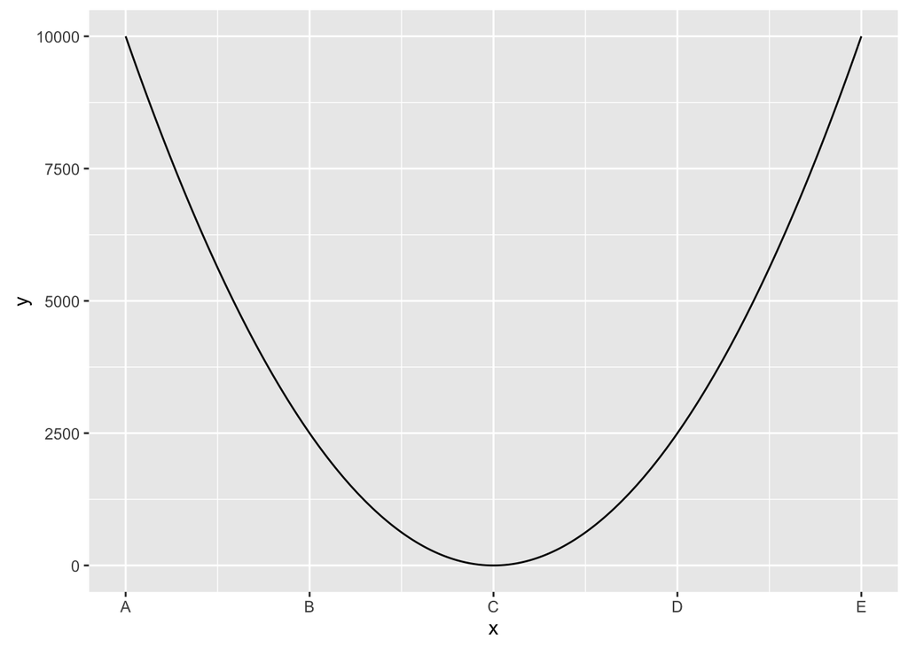

```r
# 50刻みにする,X軸ラベルはAからEとする
g + scale_x_continuous(breaks=seq(-100,100,50),labels=c("A","B","C","D","E"))
```

軸目盛りを独自に指定することもできます．

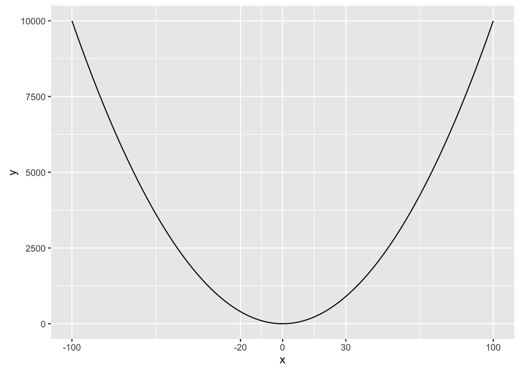

```r
g + scale_x_continuous(breaks=c(-100,-20,0,30,100))
```

# scale_y_continuous

同じようにY軸も scale_y_continuous を使ってカスタマイズすることができます．

まず，軸目盛りを変更します．

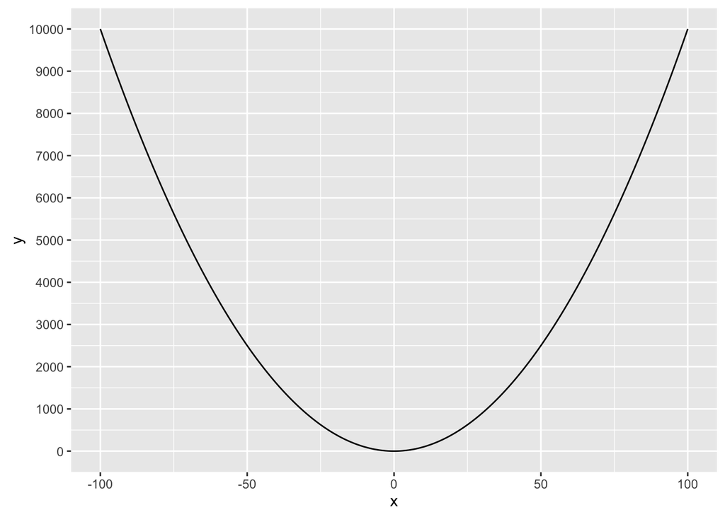

```r
# 1000刻みにする
g + scale_y_continuous(breaks=seq(0,100^2,1000))
```

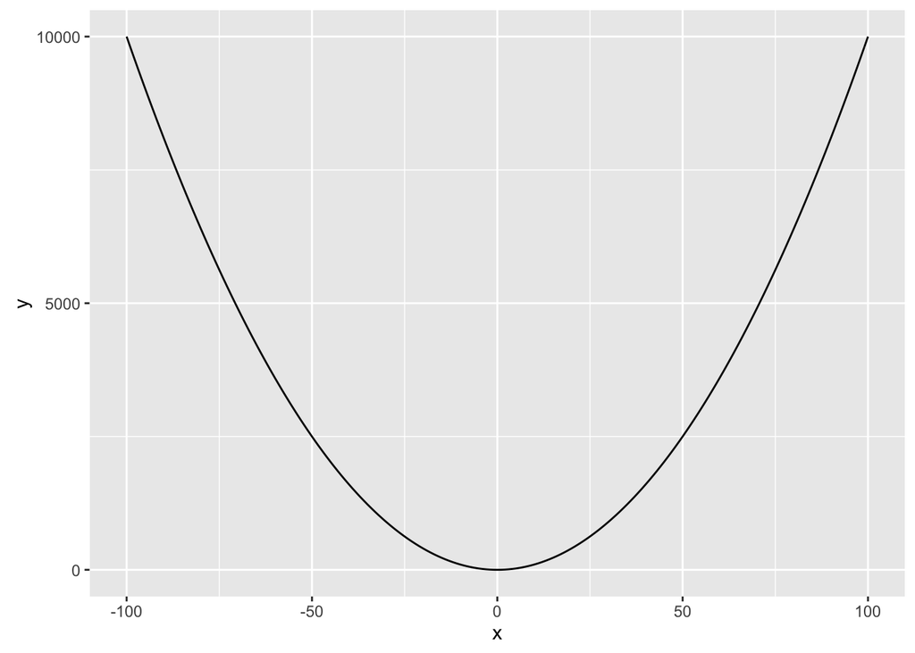

```r
# 5000刻みにする
g + scale_y_continuous(breaks=seq(0,100^2,5000))
```

つぎに軸ラベルも変更します．

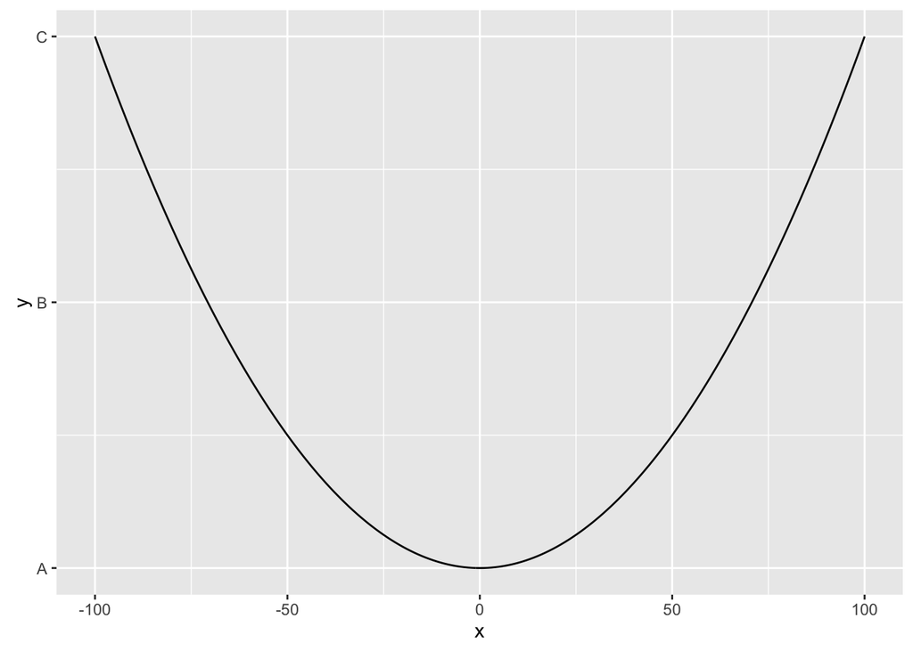

```r
# ラベルをアルファベットにする
g + scale_y_continuous(breaks=seq(0,100^2,5000),labels=c("A","B","C"))
```

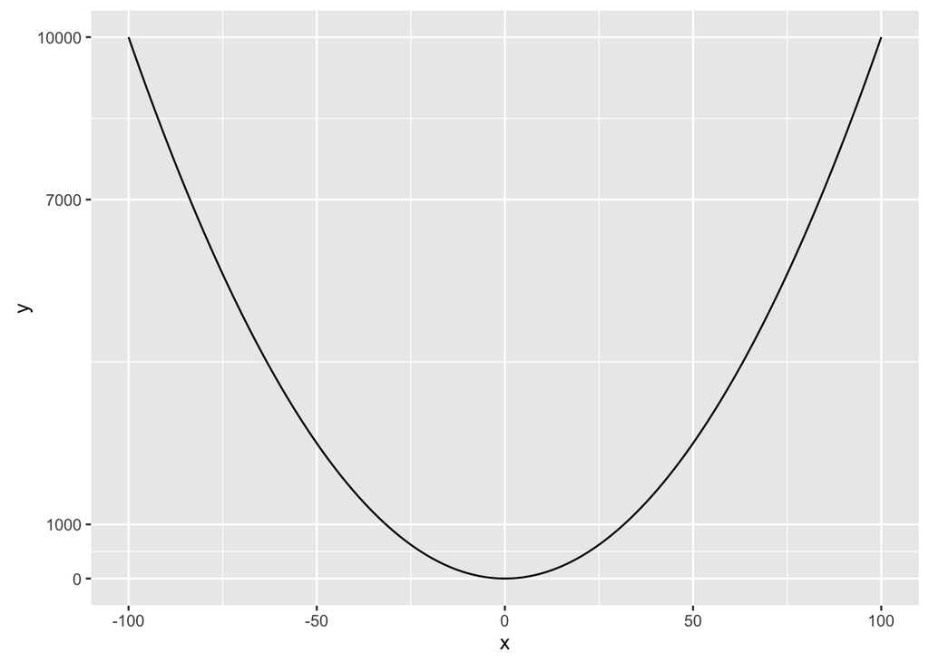

```r
# 目盛りを独自に設定する
g + scale_y_continuous(breaks=c(0,1000,7000,100^2))
```

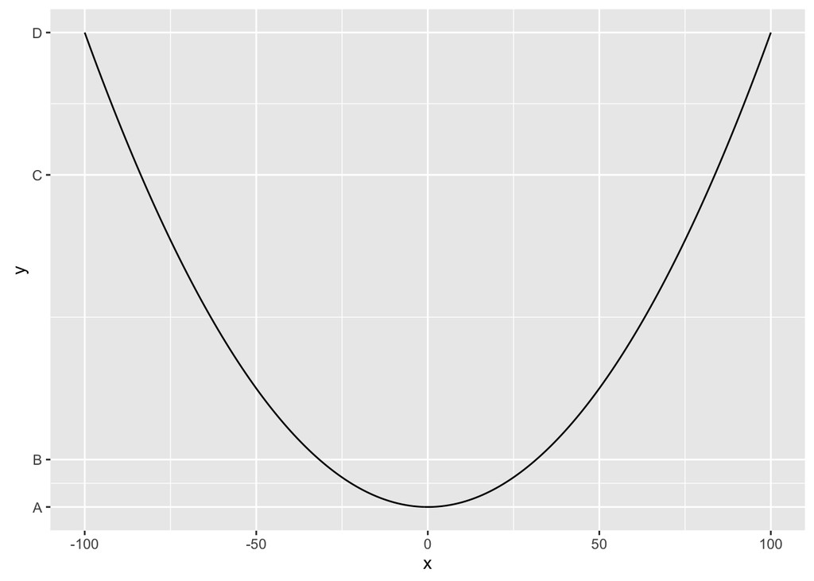

```r
# 当然ラベルも変更できる
g + scale_y_continuous(breaks=c(0,1000,7000,100^2),labels=c("A","B","C","D"))
```

# その他

trans オプションを指定するれば対数目盛りにすることもできます．

```r
g
```

[output not shown]

```r
g+scale_y_continuous(trans = "identity")
```

[output not shown]

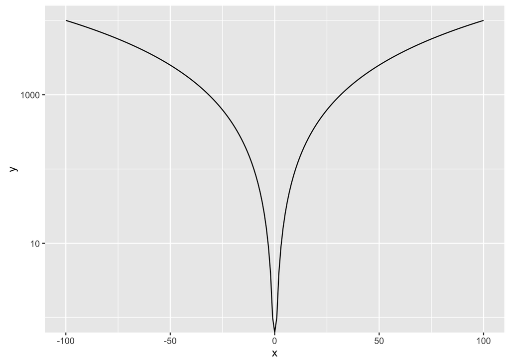

```r
g+scale_y_continuous(trans = "log10")
```

scale_y_continuous(trans = “log10”) にはエイリアス（別名） scale_y_log10() が定義されています．

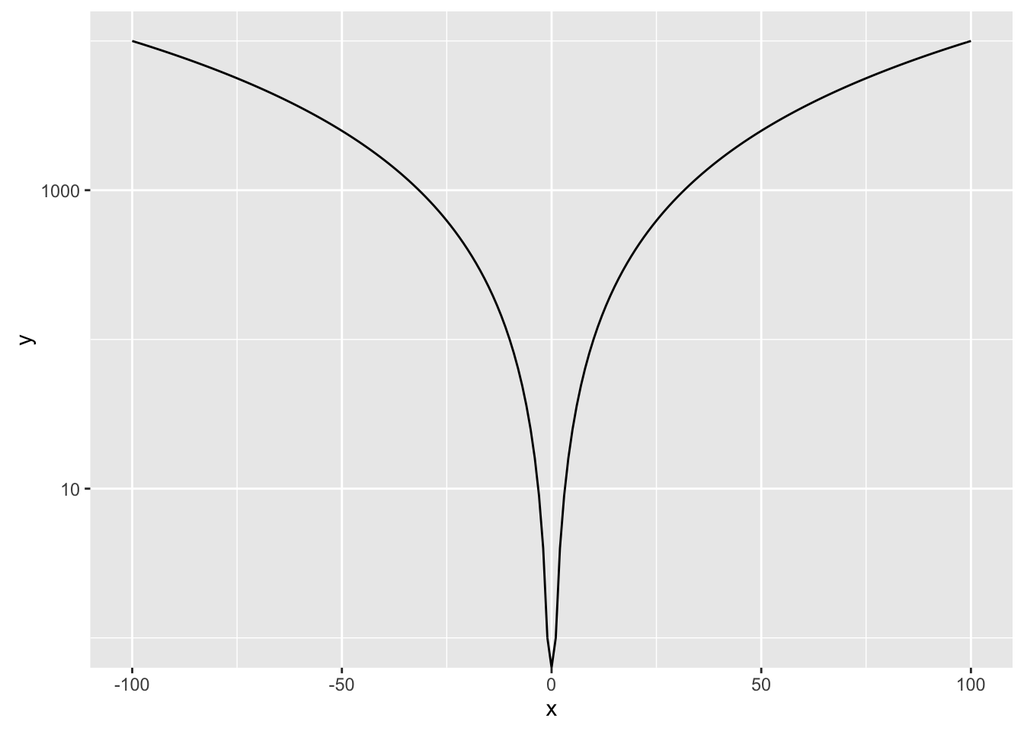

```r
g+scale_y_log10()
```

その他にも色々な変換が可能です．

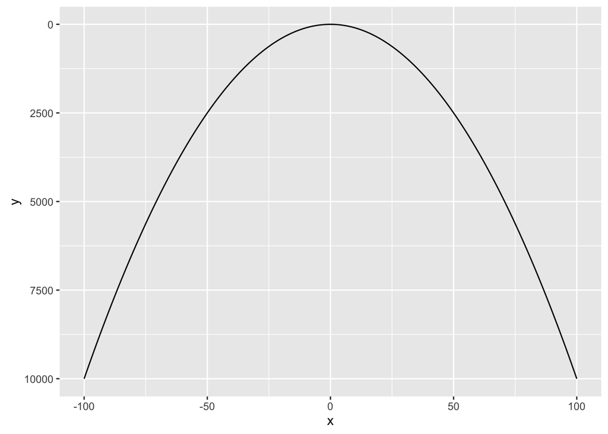

```r
g+scale_y_continuous(trans = "reverse")
```

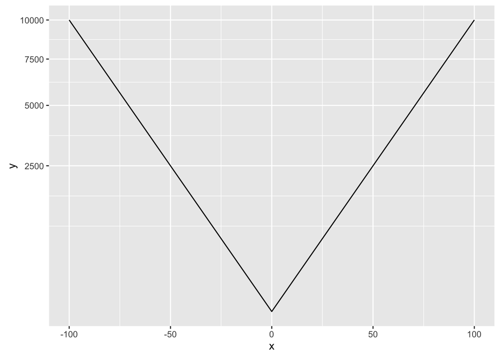

```r
g+scale_y_continuous(trans="sqrt")
```

詳しくはヘルプを参照してください．

```r
?scale_x_continuous
```

戻る

Masaharu Hayashi を著作者とするこの 作品 は [クリエイティブ・コモンズの 表示 4.0 国際 ライセンス](http://creativecommons.org/licenses/by/4.0/)で提供されています。